# Data Analysis Library

## PANDAS

https://pandas.pydata.org/

● Library for manipulation, structuring and analysis

● High performance (NumPy) and ease of use

● Resolves the 5 fundamental steps to data analysis: Reading, Preparing, Manipulating, Modeling and Analyzing

● High performance (NumPy) and ease of use

● Resolves the 5 fundamental steps to data analysis: Reading, Preparing, Manipulating, Modeling and Analyzing

● Used in various academic and professional domains: Science, Engineering, Finance, Economics, Health,...

[figure not shown]

### Methods and functions for analysis variability:

- Input / Output

`read_csv, to_csv, read_excel, to_excel`

- Basic functionalities for dataframes

`count(), sum(), mean(), min(), max()`

- Advanced indexing

`iloc, loc, ix, boolean indexing, querying, isin`

- Assignment/Re-assignment of new indexes

`set_index(), reset_index(), rename()`

- Data duplication

`unique(), duplicated(), drop_duplicates`

- Data grouping

`groupby, transform`

- Missing data handling

`dropna, fillna`

- Data combination

`merge, join, concatenate`

- Date formatting

`datetime(), strftime()`

- Data restructuring

`pivot, stack`

- Iterations

`iterrows(), itertuples()`

- Application of external functions

`apply()`

- Treatment of textual information

`lower(), upper(), len()`

## Practice Pandas

```python
import pandas as pd
# File url
url = 'https://github.com/E-man85/ML-PY/raw/main/03-data/sampledata.xls'
# Read directly from GitHub with pandas
df1 = pd.read_excel(url, sheet_name=0, engine='xlrd')
# Show first 5 rows of dataframe
df1.head()
```

|  | OrderDate | Region | Rep | Item | Units | Unit Cost | Total |
| --- | --- | --- | --- | --- | --- | --- | --- |
| 0 | 2018-01-06 | East | Jones | Pencil | 95 | 1.99 | 189.05 |
| 1 | 2018-01-23 | Central | Kivell | Binder | 50 | 19.99 | 999.50 |
| 2 | 2018-02-09 | Central | Jardine | Pencil | 36 | 4.99 | 179.64 |
| 3 | 2018-02-26 | Central | Gill | Pen | 27 | 19.99 | 539.73 |
| 4 | 2018-03-15 | West | Sorvino | Pencil | 56 | 2.99 | 167.44 |

```python
# rename columns
df1.rename(columns={'OrderDate':'Order_Date'}, inplace=True) #implace=true rewrites the original data frame
df1.rename(columns={'Unit Cost':'Unit_Cost'}, inplace=True)
df1.head()
```

|  | Order_Date | Region | Rep | Item | Units | Unit_Cost | Total |
| --- | --- | --- | --- | --- | --- | --- | --- |
| 0 | 2018-01-06 | East | Jones | Pencil | 95 | 1.99 | 189.05 |
| 1 | 2018-01-23 | Central | Kivell | Binder | 50 | 19.99 | 999.50 |
| 2 | 2018-02-09 | Central | Jardine | Pencil | 36 | 4.99 | 179.64 |
| 3 | 2018-02-26 | Central | Gill | Pen | 27 | 19.99 | 539.73 |
| 4 | 2018-03-15 | West | Sorvino | Pencil | 56 | 2.99 | 167.44 |

```python
# First lines
df1.head()
```

|  | Order_Date | Region | Rep | Item | Units | Unit_Cost | Total |
| --- | --- | --- | --- | --- | --- | --- | --- |
| 0 | 2018-01-06 | East | Jones | Pencil | 95 | 1.99 | 189.05 |
| 1 | 2018-01-23 | Central | Kivell | Binder | 50 | 19.99 | 999.50 |
| 2 | 2018-02-09 | Central | Jardine | Pencil | 36 | 4.99 | 179.64 |
| 3 | 2018-02-26 | Central | Gill | Pen | 27 | 19.99 | 539.73 |
| 4 | 2018-03-15 | West | Sorvino | Pencil | 56 | 2.99 | 167.44 |

```python
# last lines
df1.tail()
```

|  | Order_Date | Region | Rep | Item | Units | Unit_Cost | Total |
| --- | --- | --- | --- | --- | --- | --- | --- |
| 39 | 2019-10-31 | Central | Andrews | Pencil | 14 | 1.29 | 18.06 |
| 40 | 2019-11-17 | Central | Jardine | Binder | 11 | 4.99 | 54.89 |
| 41 | 2019-12-04 | Central | Jardine | Binder | 94 | 19.99 | 1879.06 |
| 42 | 2019-12-21 | Central | Andrews | Binder | 28 | 4.99 | 139.72 |
| 43 | 2019-12-21 | Central | Andrews | Binder | 28 | 4.99 | 139.72 |

```python
# General information
df1.info()
```

```
<class 'pandas.core.frame.DataFrame'>
RangeIndex: 44 entries, 0 to 43
Data columns (total 7 columns):
 #   Column      Non-Null Count  Dtype
---  ------      --------------  -----
 0   Order_Date  44 non-null     datetime64[ns]
 1   Region      44 non-null     object
 2   Rep         44 non-null     object
 3   Item        44 non-null     object
 4   Units       44 non-null     int64
 5   Unit_Cost   44 non-null     float64
 6   Total       44 non-null     float64
dtypes: datetime64[ns](1), float64(2), int64(1), object(3)
memory usage: 2.5+ KB
```

```python
# Summary statistics
df1.describe()
```

|  | Units | Unit_Cost | Total |
| --- | --- | --- | --- |
| count | 44.000000 | 44.000000 | 44.000000 |
| mean | 48.840909 | 19.960455 | 449.263636 |
| std | 29.899789 | 46.848309 | 444.366640 |
| min | 2.000000 | 1.290000 | 9.030000 |
| 25% | 27.750000 | 4.490000 | 139.877500 |
| 50% | 51.500000 | 4.990000 | 277.620000 |
| 75% | 74.250000 | 16.990000 | 587.770000 |
| max | 96.000000 | 275.000000 | 1879.060000 |

```python
# summary statistics specifying variables
df1[['Units','Total']].describe()
```

|  | Units | Total |
| --- | --- | --- |
| count | 44.000000 | 44.000000 |
| mean | 48.840909 | 449.263636 |
| std | 29.899789 | 444.366640 |
| min | 2.000000 | 9.030000 |
| 25% | 27.750000 | 139.877500 |
| 50% | 51.500000 | 277.620000 |
| 75% | 74.250000 | 587.770000 |
| max | 96.000000 | 1879.060000 |

```python
# change output formatting
pd.set_option('display.float_format', lambda x: '%.2f' % x)
df1.head(5)
```

|  | Order_Date | Region | Rep | Item | Units | Unit_Cost | Total |
| --- | --- | --- | --- | --- | --- | --- | --- |
| 0 | 2018-01-06 | East | Jones | Pencil | 95 | 1.99 | 189.05 |
| 1 | 2018-01-23 | Central | Kivell | Binder | 50 | 19.99 | 999.50 |
| 2 | 2018-02-09 | Central | Jardine | Pencil | 36 | 4.99 | 179.64 |
| 3 | 2018-02-26 | Central | Gill | Pen | 27 | 19.99 | 539.73 |
| 4 | 2018-03-15 | West | Sorvino | Pencil | 56 | 2.99 | 167.44 |

```python
# select lines
df1[0:3]
```

|  | Order_Date | Region | Rep | Item | Units | Unit_Cost | Total |
| --- | --- | --- | --- | --- | --- | --- | --- |
| 0 | 2018-01-06 | East | Jones | Pencil | 95 | 1.99 | 189.05 |
| 1 | 2018-01-23 | Central | Kivell | Binder | 50 | 19.99 | 999.50 |
| 2 | 2018-02-09 | Central | Jardine | Pencil | 36 | 4.99 | 179.64 |

```python
# remove column
df1.drop(['Total'], axis = 1, inplace = True)# axis 1 means columns 0 means rows
df1.head(5)
```

|  | Order_Date | Region | Rep | Item | Units | Unit_Cost |
| --- | --- | --- | --- | --- | --- | --- |
| 0 | 2018-01-06 | East | Jones | Pencil | 95 | 1.99 |
| 1 | 2018-01-23 | Central | Kivell | Binder | 50 | 19.99 |
| 2 | 2018-02-09 | Central | Jardine | Pencil | 36 | 4.99 |
| 3 | 2018-02-26 | Central | Gill | Pen | 27 | 19.99 |
| 4 | 2018-03-15 | West | Sorvino | Pencil | 56 | 2.99 |

```python
# operations between columns
df1['New_Total'] = df1['Units'] * df1['Unit_Cost'] # basic operation
df1['New_Total'].head()
```

```
0   189.05
1   999.50
2   179.64
3   539.73
4   167.44
Name: New_Total, dtype: float64
```

```python
# select rows according to criteria
df1.query("Region == 'East'")
```

|  | Order_Date | Region | Rep | Item | Units | Unit_Cost | New_Total |
| --- | --- | --- | --- | --- | --- | --- | --- |
| 0 | 2018-01-06 | East | Jones | Pencil | 95 | 1.99 | 189.05 |
| 5 | 2018-04-01 | East | Jones | Binder | 60 | 4.99 | 299.40 |
| 9 | 2018-06-08 | East | Jones | Binder | 60 | 8.99 | 539.40 |
| 11 | 2018-07-12 | East | Howard | Binder | 29 | 1.99 | 57.71 |
| 12 | 2018-07-29 | East | Parent | Binder | 81 | 19.99 | 1619.19 |
| 13 | 2018-08-15 | East | Jones | Pencil | 35 | 4.99 | 174.65 |
| 15 | 2018-09-18 | East | Jones | Pen Set | 16 | 15.99 | 255.84 |
| 17 | 2018-10-22 | East | Jones | Pen | 64 | 8.99 | 575.36 |
| 18 | 2018-11-08 | East | Parent | Pen | 15 | 19.99 | 299.85 |
| 21 | 2018-12-29 | East | Parent | Pen Set | 74 | 15.99 | 1183.26 |
| 24 | 2019-02-18 | East | Jones | Binder | 4 | 4.99 | 19.96 |
| 28 | 2019-04-27 | East | Howard | Pen | 96 | 4.99 | 479.04 |
| 32 | 2019-07-04 | East | Jones | Pen Set | 62 | 4.99 | 309.38 |

```python
# select rows according to criteria
df1.query("(Region == 'East') & (Units < 10)")
```

|  | Order_Date | Region | Rep | Item | Units | Unit_Cost | New_Total |
| --- | --- | --- | --- | --- | --- | --- | --- |
| 24 | 2019-02-18 | East | Jones | Binder | 4 | 4.99 | 19.96 |

```python
# reindex for date
df1.set_index('Order_Date', inplace=True)
df1.head(5)
```

| Order_Date | Region | Rep | Item | Units | Unit_Cost | New_Total |
| --- | --- | --- | --- | --- | --- | --- |
| 2018-01-06 | East | Jones | Pencil | 95 | 1.99 | 189.05 |
| 2018-01-23 | Central | Kivell | Binder | 50 | 19.99 | 999.50 |
| 2018-02-09 | Central | Jardine | Pencil | 36 | 4.99 | 179.64 |
| 2018-02-26 | Central | Gill | Pen | 27 | 19.99 | 539.73 |
| 2018-03-15 | West | Sorvino | Pencil | 56 | 2.99 | 167.44 |

```python
# select by date range
df1.loc['2018-10-1':'2018-12-31']
```

| Order_Date | Region | Rep | Item | Units | Unit_Cost | New_Total |
| --- | --- | --- | --- | --- | --- | --- |
| 2018-10-05 | Central | Morgan | Binder | 28 | 8.99 | 251.72 |
| 2018-10-22 | East | Jones | Pen | 64 | 8.99 | 575.36 |
| 2018-11-08 | East | Parent | Pen | 15 | 19.99 | 299.85 |
| 2018-11-25 | Central | Kivell | Pen Set | 96 | 4.99 | 479.04 |
| 2018-12-12 | Central | Smith | Pencil | 67 | 1.29 | 86.43 |
| 2018-12-29 | East | Parent | Pen Set | 74 | 15.99 | 1183.26 |

```python
df1.loc['2019-02']
```

| Order_Date | Region | Rep | Item | Units | Unit_Cost | New_Total |
| --- | --- | --- | --- | --- | --- | --- |
| 2019-02-01 | Central | Smith | Binder | 87 | 15.00 | 1305.00 |
| 2019-02-18 | East | Jones | Binder | 4 | 4.99 | 19.96 |

```python
# resampling by date
df1.resample('Y').sum(numeric_only=True) # group by year
```

| Order_Date | Units | Unit_Cost | New_Total |
| --- | --- | --- | --- |
| 2018-12-31 | 1178 | 306.09 | 9258.34 |
| 2019-12-31 | 971 | 572.17 | 10509.26 |

```python
# resampling by date
df1.resample('M').sum(numeric_only=True) # Group by month
```

| Order_Date | Units | Unit_Cost | New_Total |
| --- | --- | --- | --- |
| 2018-01-31 | 145 | 21.98 | 1188.55 |
| 2018-02-28 | 63 | 24.98 | 719.37 |
| 2018-03-31 | 56 | 2.99 | 167.44 |
| 2018-04-30 | 135 | 6.98 | 448.65 |
| 2018-05-31 | 122 | 6.98 | 512.78 |
| 2018-06-30 | 150 | 13.98 | 988.50 |
| 2018-07-31 | 110 | 21.98 | 1676.90 |
| 2018-08-31 | 35 | 4.99 | 174.65 |
| 2018-09-30 | 18 | 140.99 | 505.84 |
| 2018-10-31 | 92 | 17.98 | 827.08 |
| 2018-11-30 | 111 | 24.98 | 778.89 |
| 2018-12-31 | 141 | 17.28 | 1269.69 |
| 2019-01-31 | 46 | 8.99 | 413.54 |
| 2019-02-28 | 91 | 19.99 | 1324.96 |
| 2019-03-31 | 57 | 24.98 | 389.43 |
| 2019-04-30 | 162 | 6.98 | 610.38 |
| 2019-05-31 | 133 | 10.28 | 787.57 |
| 2019-06-30 | 5 | 125.00 | 625.00 |
| 2019-07-31 | 117 | 17.48 | 996.33 |
| 2019-08-31 | 45 | 298.95 | 1830.90 |
| 2019-09-30 | 83 | 3.28 | 160.27 |
| 2019-10-31 | 71 | 21.28 | 1157.49 |
| 2019-11-30 | 11 | 4.99 | 54.89 |
| 2019-12-31 | 150 | 29.97 | 2158.50 |

```python
# resampling by date
df1.resample('3M').sum(numeric_only=True) #group by 3 months
```

| Order_Date | Units | Unit_Cost | New_Total |
| --- | --- | --- | --- |
| 2018-01-31 | 145 | 21.98 | 1188.55 |
| 2018-04-30 | 254 | 34.95 | 1335.46 |
| 2018-07-31 | 382 | 42.94 | 3178.18 |
| 2018-10-31 | 145 | 163.96 | 1507.57 |
| 2019-01-31 | 298 | 51.25 | 2462.12 |
| 2019-04-30 | 310 | 51.95 | 2324.77 |
| 2019-07-31 | 255 | 152.76 | 2408.90 |
| 2019-10-31 | 199 | 323.51 | 3148.66 |
| 2020-01-31 | 161 | 34.96 | 2213.39 |

```python
# new variable with 2 month averages
bimonthly = df1.resample('2M').mean(numeric_only=True)
bimonthly
```

| Order_Date | Units | Unit_Cost | New_Total |
| --- | --- | --- | --- |
| 2018-01-31 | 72.50 | 10.99 | 594.27 |
| 2018-03-31 | 39.67 | 9.32 | 295.60 |
| 2018-05-31 | 64.25 | 3.49 | 240.36 |
| 2018-07-31 | 65.00 | 8.99 | 666.35 |
| 2018-09-30 | 17.67 | 48.66 | 226.83 |
| 2018-11-30 | 50.75 | 10.74 | 401.49 |
| 2019-01-31 | 62.33 | 8.76 | 561.08 |
| 2019-03-31 | 37.00 | 11.24 | 428.60 |
| 2019-05-31 | 73.75 | 4.32 | 349.49 |
| 2019-07-31 | 40.67 | 47.49 | 540.44 |
| 2019-09-30 | 32.00 | 75.56 | 497.79 |
| 2019-11-30 | 27.33 | 8.76 | 404.13 |
| 2020-01-31 | 50.00 | 9.99 | 719.50 |

```python
# group by column values and calculate statistics
df1.groupby(['Region']).sum(numeric_only = True)
```

| Region | Units | Unit_Cost | New_Total |
| --- | --- | --- | --- |
| Central | 1227 | 437.44 | 11278.79 |
| East | 691 | 118.87 | 6002.09 |
| West | 231 | 321.95 | 2486.72 |

```python
# group by two columns values and calculate statistics
df1.groupby(['Region','Rep']).sum(numeric_only = True)
```

| Region | Rep | Units | Unit_Cost | New_Total |
| --- | --- | --- | --- | --- |
| Central | Andrews | 211 | 15.25 | 578.09 |
|  | Gill | 213 | 40.55 | 1749.87 |
|  | Jardine | 281 | 39.95 | 2812.19 |
|  | Kivell | 193 | 173.93 | 3109.44 |
|  | Morgan | 173 | 26.47 | 1387.77 |
|  | Smith | 156 | 141.29 | 1641.43 |
| East | Howard | 125 | 6.98 | 536.75 |
|  | Jones | 396 | 55.92 | 2363.04 |
|  | Parent | 170 | 55.97 | 3102.30 |
| West | Sorvino | 142 | 299.97 | 1283.61 |
|  | Thompson | 89 | 21.98 | 1203.11 |

```python
# group by 2 columns and apply various aggregate functions to the units column
df1.groupby(['Region','Rep']).Units.agg(['sum', 'min', 'max', 'mean'])
```

| Region | Rep | sum | min | max | mean |
| --- | --- | --- | --- | --- | --- |
| Central | Andrews | 211 | 14 | 75 | 42.20 |
|  | Gill | 213 | 7 | 80 | 42.60 |
|  | Jardine | 281 | 11 | 94 | 56.20 |
|  | Kivell | 193 | 5 | 96 | 48.25 |
|  | Morgan | 173 | 28 | 90 | 57.67 |
|  | Smith | 156 | 2 | 87 | 52.00 |
| East | Howard | 125 | 29 | 96 | 62.50 |
|  | Jones | 396 | 4 | 95 | 49.50 |
|  | Parent | 170 | 15 | 81 | 56.67 |
| West | Sorvino | 142 | 3 | 76 | 35.50 |
|  | Thompson | 89 | 32 | 57 | 44.50 |

## Ploting with Pandas

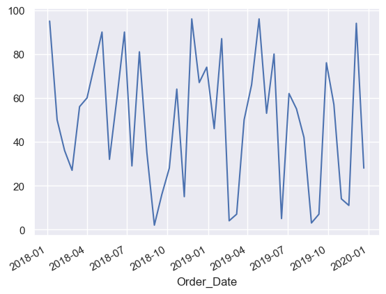

```python
import seaborn as sns
# change seaborn's theme, default theme, which is "darkgrid".
sns.set()
df1['Units'].plot() # x=indice, y=valor
```

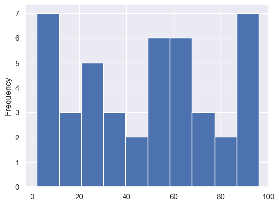

```python
# histogram
df1['Units'].plot.hist(stacked=False, bins=10)
```

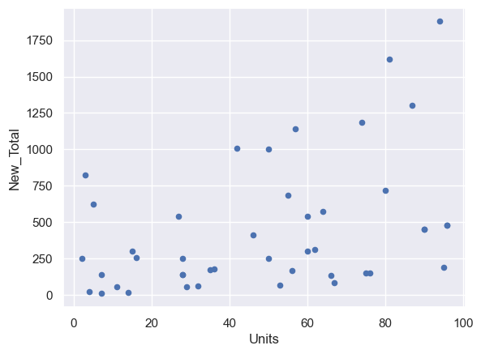

```python
# scatter plot
df1.plot.scatter(x='Units', y='New_Total')
```

## Read a new file from git hub

```python
from pandas.plotting import scatter_matrix
# File url
url = 'https://github.com/E-man85/ML-PY/raw/main/03-data/winequality.xls'
# Read directly from GitHub with pandas
df1 = pd.read_excel(url, sheet_name=0, engine='xlrd')
# Show first 5 rows of dataframe
df1.head()
```

|  | type | fixed_acidity | volatile_acidity | citric_acid | residual_sugar | chlorides | free_sulfur_dioxide | total_sulfur_dioxide | density | pH | sulphates | alcohol | X | Y | quality |
| --- | --- | --- | --- | --- | --- | --- | --- | --- | --- | --- | --- | --- | --- | --- | --- |
| 0 | red | 7.40 | 0.70 | 0.00 | 1.90 | 0.08 | 11.00 | 34.00 | 1.00 | 3.51 | 0.56 | 9.40 | -5133.04 | 274269.66 | 5 |
| 1 | red | 7.80 | 0.88 | 0.00 | 2.60 | 0.10 | 25.00 | 67.00 | 1.00 | 3.20 | 0.68 | 9.80 | -19891.40 | 200352.23 | 5 |
| 2 | red | 7.80 | 0.76 | 0.04 | 2.30 | 0.09 | 15.00 | 54.00 | 1.00 | 3.26 | 0.65 | 9.80 | -20344.63 | 223184.24 | 5 |
| 3 | red | 11.20 | 0.28 | 0.56 | 1.90 | 0.07 | 17.00 | 60.00 | 1.00 | 3.16 | 0.58 | 9.80 | -39206.75 | 233633.25 | 6 |
| 4 | red | 7.40 | 0.70 | 0.00 | 1.90 | 0.08 | 11.00 | 34.00 | 1.00 | 3.51 | 0.56 | 9.40 | -30277.81 | 223382.33 | 5 |

```python
# correlation between columns
matcorr = df1.corr(numeric_only = True)
matcorr
```

|  | fixed_acidity | volatile_acidity | citric_acid | residual_sugar | chlorides | free_sulfur_dioxide | total_sulfur_dioxide | density | pH | sulphates | alcohol | X | Y | quality |
| --- | --- | --- | --- | --- | --- | --- | --- | --- | --- | --- | --- | --- | --- | --- |
| fixed_acidity | 1.00 | 0.22 | 0.32 | -0.11 | 0.30 | -0.28 | -0.33 | 0.46 | -0.25 | 0.30 | -0.10 | -0.00 | -0.01 | -0.08 |
| volatile_acidity | 0.22 | 1.00 | -0.38 | -0.20 | 0.38 | -0.35 | -0.41 | 0.27 | 0.26 | 0.23 | -0.04 | -0.01 | -0.02 | -0.27 |
| citric_acid | 0.32 | -0.38 | 1.00 | 0.14 | 0.04 | 0.13 | 0.20 | 0.10 | -0.33 | 0.06 | -0.01 | 0.01 | 0.00 | 0.09 |
| residual_sugar | -0.11 | -0.20 | 0.14 | 1.00 | -0.13 | 0.40 | 0.50 | 0.55 | -0.27 | -0.19 | -0.36 | 0.01 | 0.01 | -0.04 |
| chlorides | 0.30 | 0.38 | 0.04 | -0.13 | 1.00 | -0.19 | -0.28 | 0.36 | 0.04 | 0.40 | -0.26 | -0.00 | -0.01 | -0.20 |
| free_sulfur_dioxide | -0.28 | -0.35 | 0.13 | 0.40 | -0.19 | 1.00 | 0.72 | 0.03 | -0.15 | -0.19 | -0.18 | -0.00 | 0.01 | 0.06 |
| total_sulfur_dioxide | -0.33 | -0.41 | 0.20 | 0.50 | -0.28 | 0.72 | 1.00 | 0.03 | -0.24 | -0.28 | -0.27 | 0.00 | 0.02 | -0.04 |
| density | 0.46 | 0.27 | 0.10 | 0.55 | 0.36 | 0.03 | 0.03 | 1.00 | 0.01 | 0.26 | -0.69 | 0.01 | -0.00 | -0.31 |
| pH | -0.25 | 0.26 | -0.33 | -0.27 | 0.04 | -0.15 | -0.24 | 0.01 | 1.00 | 0.19 | 0.12 | 0.00 | 0.00 | 0.02 |
| sulphates | 0.30 | 0.23 | 0.06 | -0.19 | 0.40 | -0.19 | -0.28 | 0.26 | 0.19 | 1.00 | -0.00 | -0.02 | -0.01 | 0.04 |
| alcohol | -0.10 | -0.04 | -0.01 | -0.36 | -0.26 | -0.18 | -0.27 | -0.69 | 0.12 | -0.00 | 1.00 | -0.01 | -0.00 | 0.44 |
| X | -0.00 | -0.01 | 0.01 | 0.01 | -0.00 | -0.00 | 0.00 | 0.01 | 0.00 | -0.02 | -0.01 | 1.00 | -0.35 | -0.00 |
| Y | -0.01 | -0.02 | 0.00 | 0.01 | -0.01 | 0.01 | 0.02 | -0.00 | 0.00 | -0.01 | -0.00 | -0.35 | 1.00 | 0.00 |
| quality | -0.08 | -0.27 | 0.09 | -0.04 | -0.20 | 0.06 | -0.04 | -0.31 | 0.02 | 0.04 | 0.44 | -0.00 | 0.00 | 1.00 |

```python
# Correlation between two columns
df1[['alcohol', 'pH']].corr()
```

|  | alcohol | pH |
| --- | --- | --- |
| alcohol | 1.00 | 0.12 |
| pH | 0.12 | 1.00 |

```python
# identification of NaN in the dataframe
df1.isnull().sum()
```

```
type                    0
fixed_acidity           0
volatile_acidity        1
citric_acid             0
residual_sugar          1
chlorides               1
free_sulfur_dioxide     1
total_sulfur_dioxide    0
density                 2
pH                      0
sulphates               0
alcohol                 0
X                       0
Y                       0
quality                 0
dtype: int64
```

```python
# Isolate control region and convert to binary
control = df1.loc[df1['type'].isin(['white'])].copy()
control['quality'] = (control['quality'] >= 7).astype(int)
control['quality'].sum()
```

```
1060
```

```python
# group by values and calculate statistics
zonasel = df1.groupby(['type']).mean()
zonasel
```

| type | fixed_acidity | volatile_acidity | citric_acid | residual_sugar | chlorides | free_sulfur_dioxide | total_sulfur_dioxide | density | pH | sulphates | alcohol | X | Y | quality |
| --- | --- | --- | --- | --- | --- | --- | --- | --- | --- | --- | --- | --- | --- | --- |
| red | 8.32 | 0.53 | 0.27 | 2.54 | 0.09 | 15.88 | 46.47 | 1.00 | 3.31 | 0.66 | 10.42 | -20856.30 | 222313.86 | 5.64 |
| white | 6.85 | 0.28 | 0.33 | 6.39 | 0.05 | 35.31 | 138.36 | 0.99 | 3.19 | 0.49 | 10.51 | -20528.20 | 223183.42 | 5.88 |

#### PLOTTING

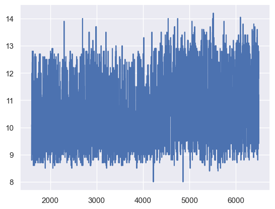

```python
# variable charts in Panda
control['alcohol'].plot() # x=indice, y=valor
```

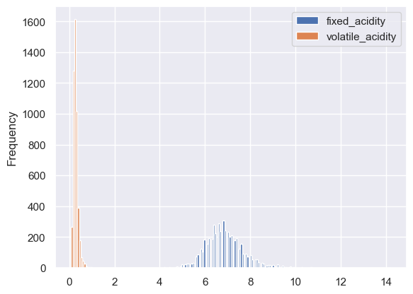

```python
# Historam
control[['fixed_acidity','volatile_acidity']].plot.hist(stacked=False, bins=200)
```

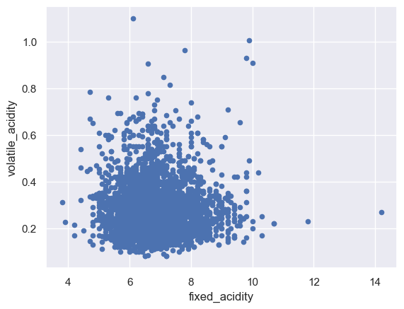

```python
 # scatter plot
control.plot.scatter(x='fixed_acidity', y='volatile_acidity')
```

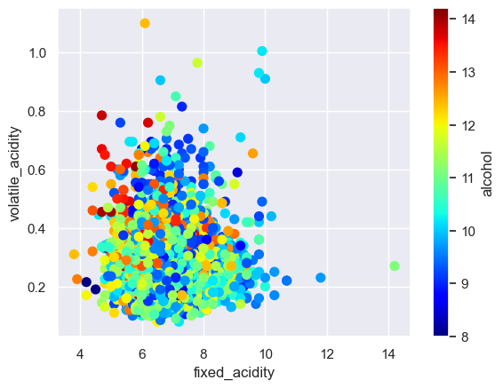

```python
control.plot.scatter(x='fixed_acidity',
                     y='volatile_acidity',
                     c='alcohol',
                     s=50,
                     colormap='jet',
                     grid='on')
```

```
array([[<AxesSubplot: xlabel='fixed_acidity', ylabel='fixed_acidity'>,
        <AxesSubplot: xlabel='volatile_acidity', ylabel='fixed_acidity'>,
        <AxesSubplot: xlabel='alcohol', ylabel='fixed_acidity'>],
       [<AxesSubplot: xlabel='fixed_acidity', ylabel='volatile_acidity'>,
        <AxesSubplot: xlabel='volatile_acidity', ylabel='volatile_acidity'>,
        <AxesSubplot: xlabel='alcohol', ylabel='volatile_acidity'>],
       [<AxesSubplot: xlabel='fixed_acidity', ylabel='alcohol'>,
        <AxesSubplot: xlabel='volatile_acidity', ylabel='alcohol'>,
        <AxesSubplot: xlabel='alcohol', ylabel='alcohol'>]], dtype=object)
```

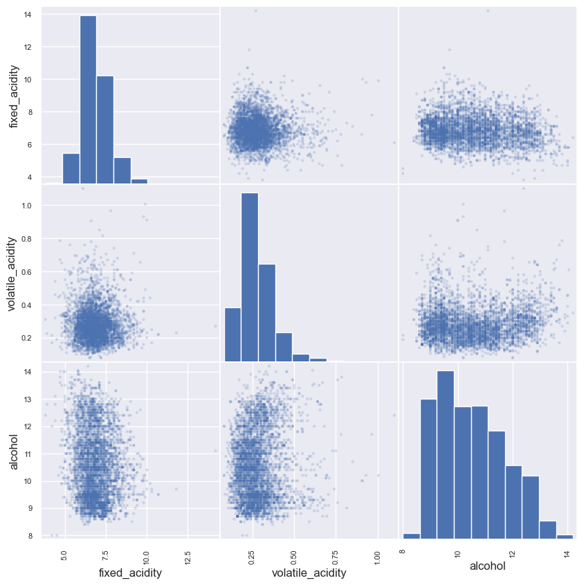

```python
# Scatter Matrix in Pandas
scatter_matrix(control[['fixed_acidity','volatile_acidity','alcohol']],
               alpha=0.2,
               figsize=(10,10),
               diagonal='hist')
```

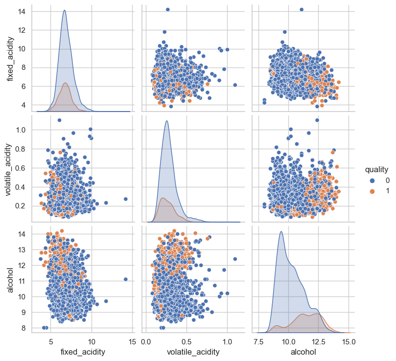

```python
# Pandas integration with Seaborn
import seaborn as sns
sns.set(style='whitegrid') #whitegrid, dark, white, ticks
sns.pairplot(control,
             vars=control[['fixed_acidity','volatile_acidity','alcohol']],
             hue='quality',
             diag_kind='kde')
```

### Export data to csv and excel

- `control.to_csv('control.csv')`
- `control.to_excel('control.xls')`